# c9w3l2_Classes_and_Methods

Robert Handsfield

01/06/2016

# First

R is interactive AND fully supports object oriented programming. Instead of OOP, it is called the *Classes and Methods System*. OOP in R is fairly different than in other languages, so PAY ATTENTION!!!

Because R inherits from the S Language, R has both S3 and S4 classes and methods

- S3 classes/methods
  - informal, klugey
  - can be called directly - but don’t ever do it
  - most base R functions are S3 style
  - sometimes called *old-style* methods by old-timers
- S4 classes/methods
  - formal and rigorous
  - cannot be called directly
  - sometimes called *new-style* by kool kids
  - implementation code in the R `methods` package

Along with classes, objects, and methods, R has *generic functions*, which are important for some reason. Generic functions figure what data type they are receiving, then call appropriate methods on that data; they DON’T DO ANYTHING ELSE.

To be a smart R programmer, read the documentation from

- `?Classes`
- `?Methods`
- `?setClass`
- `?setMethod`
- `?setGeneric`

## Second

Classes

- Classes defined with `methods::setClass()`
- Instantiated by `methods::new()`

Methods

- Class methods defined with `methods::setMethod`

Generic Function * defined with `methods::setGeneric()`

## Third

The class of all objects can be determined with the `class()` function. The most basic classes, like string, int, etc, are called *atomic* classes. More complicated data objects (duh) can have their class types returned in the same manner.

```r
# atomic classes
class(16);
```

```
## [1] "numeric"
```

```r
class("a");
```

```
## [1] "character"
```

```r
class(5.3);
```

```
## [1] "numeric"
```

```r
# data classes
x <- rnorm(100);
y <- rnorm(100);
fit <- lm(y ~ x); ## Linear regression model
class(fit);
```

```
## [1] "lm"
```

## Fourth

Basic information about methods can be printed by typing the method name.

```r
mean
```

```
## function (x, ...)
## UseMethod("mean")
## <bytecode: 0x2c9d8a8>
## <environment: namespace:base>
```

Methods can be investigated more deeply with `utils::methods()`. Calling `methods` on the generic function `base::mean()` shows that `mean()` can call five different averaging methods, one each for: dates, numbers, time differences, POSIXct, POSIXlt. It all depends on the class of the input data, and `base::mean()` figures this out for us.

```r
# an S3 generic function
methods("mean");
```

```
## [1] mean.Date     mean.default  mean.difftime mean.POSIXct  mean.POSIXlt
## see '?methods' for accessing help and source code
```

Loading new packages can add methods called by `mean()`.

## Fifth

The S4 generic function `methods::show()` (S4 equivalent of print) can also call many different object methods.

```r
methods("show")
```

```
##  [1] show,ANY-method
##  [2] show,classGeneratorFunction-method
##  [3] show,classRepresentation-method
##  [4] show,envRefClass-method
##  [5] show,externalRefMethod-method
##  [6] show,genericFunction-method
##  [7] show,genericFunctionWithTrace-method
##  [8] show,MethodDefinition-method
##  [9] show,MethodDefinitionWithTrace-method
## [10] show,MethodSelectionReport-method
## [11] show,MethodWithNext-method
## [12] show,MethodWithNextWithTrace-method
## [13] show,namedList-method
## [14] show,ObjectsWithPackage-method
## [15] show,oldClass-method
## [16] show,refClassRepresentation-method
## [17] show,refMethodDef-method
## [18] show,refObjectGenerator-method
## [19] show,signature-method
## [20] show,sourceEnvironment-method
## [21] show,traceable-method
## see '?methods' for accessing help and source code
```

```r
# or
# showMethods("show")
```

## How Generic Functions Work

The mechanism for methods/ generic functions is

0. The first argument of a generic function is an object of a particular class (there may be other arguments)
1. The generic function checks the class of the object.
2. A search is done to see if there is an appropriate method for that class.
3. If there exists a method for that class, then that method is called on the object and we’re done.
4. If a method for that class does not exist, a search is done to see if there is a default method for the generic. If a default exists, then the default method is called.
5. If a default method doesn’t exist, then an error is thrown.

## Examining Method Code

Most method code is hidden, but you can view it like this

- S3: `getS3method(<name of generic>, <class>)`
  - `utils::getS3ethod()`
- S4: `getMethod(<name of generic>, <signature>)`
  - `methods::getMethod()`

## Creating S4 Classes

S4 classes are defined with `methods::setClass()`. At minimum, the class needs a name.

`setClass` example

```r
setClass(Class, representation, prototype, contains=character(), validity,
     access, where, version, sealed, package, S3methods = FALSE, slots)
```

The arguments are, in order of priority

1. Class = name of the class
2. slots = class variables in format `list(variable="type", etc)`
3. contains = superclasses in format `list("superclass")`
   - superclasses must be in same type-order as slot elements

Class variables are called *slots* and are statically typed. Slots are defined via the `slots` argument of `setClass()` like this

```r
# create list of slot='type' with list() or vector()
classVars = list(x="numeric", y="integer", m="lm", b="logical")

# create a list of parent classes (optional)
superClass = list("numeric", "integer", "lm")

setClass(Class = "myClass", slots = classVars, contains = superClass ...)
```

- Define new class with `methods::setClass()`
- Define slots (class variables) with the `slots` argument of `setClass()`
  - or use `methods::representation()` (almost deprecated)
  - slots are accessible with the `@` operator
- Define methods with `methods::setMethod()`
- View class structure with `methods::showClass()`

### Example - A Polygon Class

```r
library(methods)

setClass("polygon", slots = c(x="numeric", y = "numeric") )
```

## Creating S4 Methods

S4 methods are created with he `setMethod()` function

```r
setMethod(f, signature=character(), definition, where = topenv(parent.frame()),
          valueClass = NULL, sealed = FALSE)
```

1. `f` = A generic function or the character-string name of the function
2. `signature` = a list of objects the function can accept
3. `definition` = the function definition, standard syntax

`setMethod()` requires both a signature **AND** an associated generic function (primitive base function like `mean` or `print`). The signature is a character vector indicating the types of objects that are accepted by the method. For example, `mean()` accepts numerics, integers, dates, date ranges, etc.

Working from the polygon class in the previous example, add a plotting method that takes a polygon object as input.

```r
library(methods)

setClass("polygon", slots = c(x="numeric", y = "numeric"))

setMethod("plot", "polygon",
      function(x, y, ...) {
        plot(x@x, x@y, type="n", ...);
        xp <- c(x@x, x@x[1]);
        yp <- c(x@y, x@y[1]);
        lines(xp, yp);
      }
      )
```

```
## [1] "plot"
```

```r
library(methods)
showMethods("plot")
```

```
## Function: plot (package graphics)
## x="ANY"
## x="polygon"
```

The signature for our class `polygon` is listed. The other signature is for the default plot method.

Let’s try it out

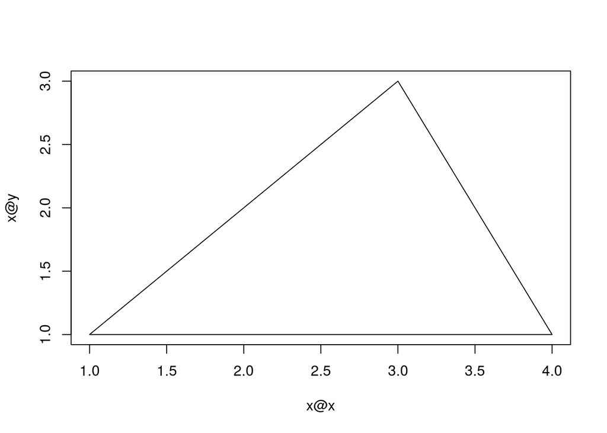

```r
# new class instance
p <- new("polygon", x = c(1,2,3,4), y = c(1,2,3,1))

plot(p)
```